# Replication Report

Monica Chang

4/24/2021

## Overview of the original paper

### What question(s) did the author(s) ask?

In the paper “Testing Theories of American Politics: Elites, Interest Groups, and Average Citizens” by Martin Gilens and Benjamin Page, the authors attempt to answer the following question: Which of the four theoretical traditions in the study of American politics - Majoritarian Electoral Democracy, Economic-Elite Domination, Majoritarian Pluralism, Biased Pluralism - provides the most accurate picture of American politics?

These theories each offer different predictions over how much independent influence the median voter, economic elites, mass-based interest groups, and business-oriented interest groups have on public policy:

- Majoritarian Electoral Democracy posits that only the median voter has substantial independent influence on policy outcomes.
- Economic-Elite Domination posits that economic elites have the most independent influence on policy outcomes, with the median voter and interest groups playing a smaller role.
- Majoritarian Pluralism posits that only organized interest groups will have substantial independent influence on policy outcomes. In particular, this theory assumes that the stands of all interest groups, taken together, generally represent the preferences of average citizens.
- Biased Pluralism posits that only organized interest groups will have substantial independent influence on policy outcomes. In particular, this theory predicts that business-oriented interest groups play a larger role.

Gilens and Page aim to test these four theoretical traditions within one statistical model.

### How did they create their dataset? What were their variables of interest?

To conduct this analysis, Gilens assembled a unique dataset of 1,779 instances between 1981 and 2002 in which a national survey of the general public asked a favor/oppose question about a proposed policy change.

For each survey question, Gilens’ team did the following work to prepare a unique dataset:

- Use the available income breakdown for each survey question’s respondents to estimate the opinions of respondents at the 10th income percentile, the 50th percentile, and the 90th percentile.
- Record how many engaged powerful interest groups were strongly in favor of, somewhat in favor of, somewhat opposed, or strongly opposed to the proposed policy change in each question. This allowed Gilens to develop a measure of Net Interest Group Alignment for all interest groups, mass-based interest groups, and business-oriented interest groups.
- Track whether the proposed policy change was actually adopted within 4 years after the question was asked.

Predictor variables:

- Policy preferences at the 50th income percentile work as a proxy for the preferences of the median voter.
- Policy preferences at the 90th income percentile work as a proxy for the preferences of the economic elite.
- Net Interest Group Alignment scores work as a proxy for the preferences of all interest groups, mass-based interest groups, and business-oriented interest groups.

Outcome variable:

- Whether or not the proposed policy change was adopted within 4 years.

### What analyses did they run? What models did they use?

First, they create a correlation matrix (Table 2) to assess the correlation between independent variables. This helps test one of Majoritarian Pluralism’s predictions - that the stands of all interest groups are positively correlated with the preferences of average citizens.

Then, they use structural equation modeling to regress policy outcome on the preferences of the median voter, the preferences of the economic elite, and the preferences of all interest groups (Table 3) to evaluate support for Majoritarian Electoral Democracy, Economic Elite Domination, and interest group pluralism.

Finally, they regress policy outcome on the preferences of the median voter, the preferences of the economic elite, the preferences of mass-based interest groups, and the preferences of business-oriented interest groups to distinguish between Majoritarian Pluralism and Biased Pluralism (Table 4).

### Why did they choose structural equation modeling?

They chose structural equation modeling to correct for correlated measurement error. Because the measures for two independent variables - the preferences of the 50th percentile voter and the preferences of the 90th percentile voter - come from a single data source (the same set of national opinion surveys), it is highly likely that the errors of these two measures are positively correlated with each other. These correlated errors tend to produce upwardly biased statistical relationships between the two independent variables. This decision is further explained in Appendix 2 of their paper (see the documents folder of my Github repository to read this appendix in detail).

### What did they conclude?

Gilens and Page conclude that economic elites and business-oriented interest groups have substantial independent impacts on U.S. policy, while mass-based interest groups and average citizens have little or no independent influence. Their results support theories of Economic-Elite Domination and Biased Pluralism.

## Overview of my replication

### Data cleaning

For my replication, I first cleaned Gilens’ publicly provided data according to the criteria laid out in the paper (excluding questions without an income breakdown, where the policy was partially adopted, or if the policy change required a Constitutional amendment or Supreme Court ruling).

After filtering the dataset to only include the 1,779 survey questions that met the criteria, I cleaned the dataset to prepare it for modeling:

First, I turned the outcome variable into a dichotomous variable so that it was coded 1 if the proposed policy change took place within four years of the survey date and 0 if it did not.

I took the logits of the imputed percent of respondents at the 50th and 90th income percentiles that favored the proposed policy change.

Then, I calculated Net Interest Group Alignment scores for all interest groups, mass-based interest groups, and business-oriented interest groups for each survey question by using the formula described in the paper:

Net Interest-Group Alignment = ln(# Strongly Favor + [0.5 * # Somewhat Favor] + 1) - ln(# Strongly Oppose + [0.5 * # Somewhat Oppose] + 1)}

Finally, I standardized all predictors to be on a scale of 0 to 1.

### Table 1 Replication

This table summarizes the main hypotheses of interest based on the four ideal types of theory.

For example, for the theory of Majoritarian Electoral Democracy to be supported, we would expect to see only the average citizen have substantial independent influence on the policy outcome.

For the theory of Dominance by Economic Elites to be supported, we would expect to see economic elites have the most substantial independent influence on the policy outcome. We would also expect some independent influence by average citizens and interest groups - especially business-oriented interest groups.

The rest of the rows can be interpreted in a similar manner.

Table 1

Theoretical predictions concerning the independent influence of sets of actors upon policy outcomes

| Theory (ideal type) | Sets of Actors Average Citizens | Sets of Actors Economic Elites | Sets of Actors All Interest Groups | Sets of Actors Mass Interest Groups | Sets of Actors Business Interest Groups |
| --- | --- | --- | --- | --- | --- |
| Majoritarian Electoral Democracy | Y | n | n | n | n |
| Dominance by Economic Elites | y | Y | y | n | y |
| Majoritarian Pluralism | y | n | Y | Y | Y |
| Biased Pluralism | n | n | y | y | Y |

n = little or no independent influence  
y = some independent influence  
Y = substantial independent influence

### Table 2 Replication

This table shows the correlations between independent variables.

The authors get the following findings from this table:

- The preferences of average citizens are positively and fairly highly correlated, across issues, with the preferences of economic elites. This means average citizens might often be observed to get their preferred policy outcomes even if they had no independent effect on policy making.
- Net interest-group stands are not substantially correlated with the preferences of average citizens. Even mass-based interest groups have a very modest correlation with the preferences of average citizens. This does *not* support Majoritarian Pluralism’s prediction - that organized interests taken together are good representatives of citizens as a whole.
- Business-oriented interest groups have a negative correlation with the preferences of average citizens. This suggests that business-oriented interest groups are opposed to the interests of average citizens.
- There is no association between the preferences of economic elites and the alignments of either mass-based or business-oriented groups. While the latter finding may be surprising, this may be because economic elites broadly prefer lower government spending whereas interest groups generally lobby for increased spending for their specific industries.

The correlation coefficients in my table are slightly different from those in the paper because I do not correct for correlated measurement error using SEM modeling (SEM modeling is outside the scope of this course). However, my findings are generally quite similar except for the following differences:

- The correlation coefficient between the preferences of average citizens and the preferences of economic elites is much higher (0.94) than what Gilens and Page get (0.78). This high correlation could be partly due to factors like sampling, question wording, question order, topics in the news at the time the survey was in the field, and so on.
- The correlation coefficient between the preferences of all interest groups and the preferences of mass-based interest groups is 0.19, whereas Gilens and Page get 0.47.
- The correlation coefficient between the preferences of all interest groups and the preferences of business-oriented interest groups is 0.64, whereas Gilens and Page get 0.96.
- The correlation coefficient between the preferences of mass-based interest groups and the preferences of business-oriented interest groups is -0.21 and statistically significant, whereas Gilens and Page get a coefficient of -0.05 that is not statistically significant.

Table 2

Correlations among independent variables

|  | Average citizens’ preferences | Economic elites’ preferences | All interest groups | Mass public interest groups |
| --- | --- | --- | --- | --- |
| Average citizens’ preferences |  |  |  |  |
| Economic elites’ preferences | 0.94*** |  |  |  |
| All interest groups | 0.04 | 0.04 |  |  |
| Mass public interest groups | 0.13*** | 0.02 | 0.19*** |  |
| Business interest groups | -0.09*** | -0.02 | 0.64*** | -0.21*** |

***p<.001; n = 1779.  
Note: Entries are correlation coefficients based on OLS regression coefficients - not SEM modeling.

### Table 3 Replication

Note: Because structural equation modeling is outside the scope of this course, I use ordinary least squares regression instead. I am able to check whether my results are correct based on Table A1 in Appendix 2 - an OLS analysis provided by Gilens that is parallel to the structural equation model presented in Table 3.

The authors get four main findings:

- When taken separately, each independent variable is strongly, positively, and significantly related to policy change.
- In the multivariate model, the independent influence of the median voter’s preferences is not significant and near-zero. This rejects the theory of Majoritarian Electoral Democracy.
- Economic elites have a substantial, highly significant, independent influence on policy outcomes.
- Organized interest groups are found to have substantial independent influence on policy outcomes.

- Whereas the regression coefficient representing the median voter’s influence in the original paper is statistically and substantively insignificant (0.03), the coefficient representing the median voter’s influence is negative, substantial, and statistically significant in my replication (-0.87). In other words, my replication indicates that a median voter’s preference in favor of a policy change is associated with a *negative* influence on the policy outcome. It would seem that Gilens and Page’s correction for correlated measurement error is crucial to get to their key finding - the fact the median voter has no significant independent influence.
- The regression coefficient representing the economic elite’s influence is much higher in my replication (1.61) than in the original paper (0.76).
- The regression coefficient representing interest group influence is slightly lower in my replication (0.49) than in the original paper (0.56).

### Figure 1 Replication

Because the magnitudes of the coefficients reported in Table 3 are hard to interpret, the authors visualize the relative influence of each set of actors. They compare how the predicted probability of policy change differs when moving from one point to another on their distributions of policy dispositions, while holding other actors’ preferences constant at their neutral points (50% favorable for average citizens and for economic elites, and a net interest-group alignment score of 0). These changing probabilities, based on the coefficients in Model 4 of Table 3, are line-graphed in Figure 1 along with bar graphs of the underlying preference distributions.

The authors get three main findings:

- When one holds the preferences of interest groups and economic elites constant, it makes very little difference what the average citizen prefers. The probability of policy change is around the same (around 0.3) whether a tiny minority or a large majority of average citizens favor a proposed policy change.
- When one holds the preferences of interest groups and average citizens constant, it makes a large difference what economic elites prefer. When 1 out of 5 economic elites favor a policy, it is adopted 18% of the time. When 4 out of 5 economic elites favor a policy, it is adopted 45% of the time.
- When one holds the preferences of average citizens and economic elites constant, it makes a large difference what interest groups prefer. When the Net Interest Group Alignment score is -2, it is adopted 21% of the time. When the Net Interest Group Alignment score is +2, it is adopted 39% of the time.

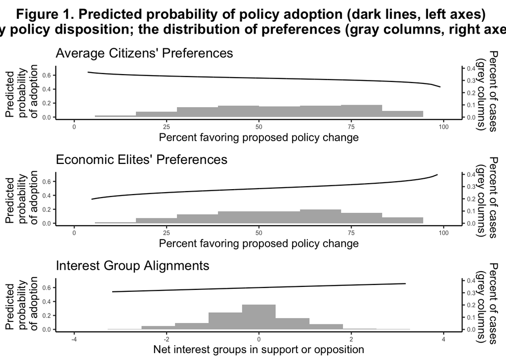

### Table 4 Replication

The authors get four main findings:

- The coefficients for both mass-based and business-oriented interest groups are positive and highly significant - but the coefficient for business groups is nearly twice as large as that for the mass groups. This supports the predictions of Biased Pluralism theories. Gilens and Page suggest that the advantage of business-oriented interest groups comes down to two factors: numerical advantage and relative cohesion. There are around twice as many business-oriented groups engaged on each policy issue. In addition, business groups are rarely found on both sides of a proposed policy change.
- The findings in Table 3 are confirmed in this analysis. The preferences of average citizens are still near-zero and not significant. Economic elites still have a substantial, positive, independent impact.

- My coefficient representing the influence of average citizens was substantial, negative, and significant (-0.895) whereas the same coefficient in the original paper was positive, near-zero, and not significant (0.05).
- My coefficient representing the influence of economic elites was (1.662) was much higher than the same coefficient in the original paper (0.78).

## Extension of the paper

The original paper does not consider the impact of party control on policy outcomes. I extended the replication by adding in a variable to indicate whether theparty of the President in the year of the survey question was a Democrat or a Republican. I was curious about whether Democratic or Republican control of the presidency was more associated with policy change.

When one holds the preferences of average citizens, economic elites, and interest groups constant, the party of the President is associated with little predictive difference. When the president is Democratic, proposed policy changes are adopted 53% of the time. When the president is Republican, proposed policy changes are adopted 55% of the time. The difference seems relatively small.

I also extended the replication by adding in a statistical interaction between party of the President and preferences of average citizens. In Unequal Democracy, Larry Bartels finds a strong impact of partisan control on the minimum wage (with the minimum wage keeping pace with inflation during Democratic administrations but declining during Republican administrations). This would seem to suggest that Democratic administrations are more responsive to the average citizen. I was curious about whether there was any differential responsiveness by the different parties to the average citizen based on this dataset.

Of course, my analysis is fairly limited as I am not considering the party in control of Congress, whether government is unified, and a whole host of other potentially confounding factors.

It appears that after adding this interaction, the coefficient for the party_pres coefficient decreases significantly and is no longer statistically significant (the standard error for the party_pres coefficient is larger in magnitude than the coefficient itself).

However, the pred50_norm:party_pres coefficient is relatively statistically significant. This coefficient represents the change in pred50_norm if the party of the President goes from Democrat to Republican. To more easily interpret this coefficient, we can convert to predicted probabilities.

When one holds the preferences of economic elites and interest groups constant, the party of the President is associated with some differential responsiveness to the average citizen.

- When the president is Democratic and 1 out of 5 average citizens favors the proposed policy change, the policy is adopted 60% of the time.
- When the president is Democratic and 4 out of 5 average citizens favors the proposed policy change, the policy is adopted 45% of the time.
- When the president is Republican and 1 out of 5 average citizens favors the proposed policy change, the policy is adopted 60% of the time.
- When the president is Republican and 4 out of 5 average citizens favors the proposed policy change, the policy is adopted 50% of the time.

It appears that Republican presidents are more responsive to the average citizen. This is surprising - as I would have expected a Democratic president to be associated with more responsiveness to the average citizen. In general, Democratic administrations tend to align themselves with “the common man”.

The implications of this are striking and present a new puzzle. Why is the Democratic Party, a party that frequently aligns itself with “the common man” and pushes for policies that are supposedly beneficial for lower-income individuals, associated with *less* governmental responsiveness to the average citizen? Some additional research questions inspired by this puzzle:

- In what policy domains were Republicans more responsive to the average citizen?
- Is the Democratic Party out of touch with what the average citizen wants in terms of social policies?
- How different are preferences on redistributive policies between average citizens and affluent voters?
- Does the average citizen prefer more downwardly redistributive policies?
- How many of the policies on the national agenda are redistributive?

## Conclusion

- Economic elites and business-oriented interest groups have substantial independent impacts on U.S. policy, while mass-based interest groups and average citizens have little or no independent influence.
- Their results support theories of Economic-Elite Domination and Biased Pluralism.

I use OLS regression instead of SEM modeling (like Gilens and Page) because SEM modeling is outside the scope of this class. This poses a limitation for how closely I am able to replicate their results. This difference in model choice results in one major difference from their original paper - the influence of the average citizen. In my analyses, the preferences of the average citizen had a substantial, *negative*, and significant influence on the policy outcome. In other words, my replication indicates that a median voter’s preference in favor of a policy change is associated with a *negative* influence on the proposed policy change getting adopted.

For my extension, I looked into whether Democratic or Republican control of the presidency was more associated with policy change. I found little influence. I also looked into whether there was any differential responsiveness to the average citizen by the different parties. I surprisingly found that Republican presidents are more responsive to the average citizen.

Future questions that could be investigated with this dataset:

- What is the impact of unified government on governmental responsiveness? Are periods of unified government associated with greater likelihood that proposed policy changes will get adopted?
- What would these results look like if this dataset was extended into the present day? Given the impact of the filibuster, has governmental responsiveness worsened?

## Data Source

The data for this paper can be found here: https://www.russellsage.org/datasets/economic-inequality-and-political-representation.

## Bibliography

Bartels, Larry M. Unequal Democracy: The Political Economy of the New Gilded Age. NEW YORK; PRINCETON; OXFORD: Princeton University Press, 2008. Accessed May 4, 2021. http://www.jstor.org/stable/j.ctt7t9ks.

Gilens, M., & Page, B. (2014). Testing Theories of American Politics: Elites, Interest Groups, and Average Citizens. Perspectives on Politics, 12(3), 564-581. doi:10.1017/S1537592714001595

O’Brien, Robert M. “Correcting Measures of Relationship between Aggregate-Level Variables.” Sociological Methodology 21 (1994): 125-65

O’Brien, Robert M. “Correcting Measures of Relationship between Aggregate-Level Variables for Both Unreliability and Correlated Errors: An Empirical Example.” Social Science Research 27, no. 2 (Jun 1998): 218-34.